# Exploring Alzheimer’s Disease Biomarkers with Data Wrangling

OLET5606 | July 2022 | The University of Sydney

Annie Bryant

# 1. Executive Summary

This project report details the exploratory analysis and cleaning of cross-sectional neuroimaging and clinical data obtained from the [Open Acess Series of Imaging Studies (OASIS): Cross-Sectional Study](https://doi.org/10.1162/jocn.2007.19.9.1498). The dataset includes 416 adult participants at various points along the cognitive continuum from normal healthy aging to dementia. Dataset features include cognitive test scores, demographic variables, and neuroimaging-derived brain volume measurements. Two different binary classification methods (logistic regression and random forest) were compared to distinguish cognitively healthy adults from those with dementia, both of which yielded an out-of-sample accuracy of 66.04%. Both classifiers highlighted normalized whole brain volume as the most relevant predictor for dementia status, which is consistent with literature linking [neurodegeneration-induced cortical thinning with cognitive decline](https://doi.org/10.1001%2Farchneurol.2011.192). Such analyses can help us understand the key factors that contribute to cognitive decline versus normative aging with an increasingly older population.

# 2. Integrative Data Analysis (IDA)

In recent years, there has been an increasing push to form multi-centre collaborations that integrate clinical, neuroimaging, and biomolecular data in a global effort to understand the multifactorial nature of dementia. Several consortiums have committed to sharing such rich datasets with academic researchers around the world, like the [Alzheimer’s Disease Neuroimaging Initiative (ADNI)](https://doi.org/10.1002/jmri.21049), the [Australian Imaging, Biomarkers, and Lifestyle (AIBL) study of aging](https://doi.org/10.1017/S1041610209009405.), and the [Open Access Series of Imaging Studies (OASIS)](https://doi.org/10.1162/jocn.2007.19.9.1498). This report leverages the third of these datsets (OASIS), with a summary of data acquisition and cleaning, visualisation, and classification analysis As this analysis is transparent and reproducible given the inclusion of all code used for this workflow, this work will be of interest to stakeholders with a shared interest in exploring the factors that collectively drive dementia, whether in the OASIS dataset or similar.

## 2.1 Assessment of Data Provenance

The OASIS Cross-Sectional study includes 416 participants of ages 18 to 96 assessed at the Washington University at Saint Louis (WUSTL) Knight Alzheimer’s Disease Research Center (ADRC). Each visit per subject included a suite of structural and functional neuroimaging sequences that capture relevant anatomical biomarkers like cortical thickness, ventricle volume, and regional metabolism. All OASIS data is maintained at the [Central XNAT server](https://wiki.xnat.org/central/oasis-on-xnat-central-60981641.html) and is available to members of the research community by submitting a [data access application](https://www.oasis-brains.org/#access). Data were provided in part by the following Principal Investigators: D. Marcus, R, Buckner, J, Csernansky J. Morris; P50 AG05681, P01 AG03991, P01 AG026276, R01 AG021910, P20 MH071616, U24 RR021382. The OASIS cross-sectional dataset has been cited by 1,443 peer-reviewed publications according to Google Scholar, underscoring the scientific merit and statistical reliability of this dataset across analyses. Moreover, the OASIS author team is comprised of several prominent neuroimaging experts at the University of Washington and Massachusetts General Hospital, lending credence to the reliability of this data source.

## 2.2 Domain Knowledge

All data and metadata accessed for this project were obtained from the [OASIS website](https://www.oasis-brains.org/#data). Any user who accesses OASIS data is required to comply with the [Data Use Agreement](https://www.oasis-brains.org/#access); as such, the author signed the data use agreement and submitted a request to access the data for this assignment. Additionally, all participants opted into the OASIS project after consenting to the release of their anonymised neuroimaging, clinical, and cognitive biomarker data, supporting the view that this is ethically sourced data.

Upon complying with the data use agreement, the OASIS-1 cross-sectional dataset (“oasis_cross-sectional.csv”) was downloaded as a CSV file from the [OASIS website](https://www.oasis-brains.org/#data) under the OASIS-1 tab. This cross-sectional dataset contains a total of 416 participants at various stages along the cognitive continuum from normative healthy aging to dementia. Of these 416, a validation cohort of 20 participants returned for a second set of observations, yielding a total of 436 observations in the dataset. Further information about this dataset can be found in the [OASIS cross-sectional data fact sheet](https://www.oasis-brains.org/files/oasis_cross-sectional_facts.pdf) and the [OASIS Data Dictionary](https://www.oasis-brains.org/files/OASIS-3_Imaging_Data_Dictionary_v1.5.pdf).

Load in data using `read.csv()`:

```r
oasis_data <- read.csv("oasis_cross-sectional.csv", na.strings = c("", "NA", "N/A"))
```

We can visualize an overview of the data structure using `skimr::skim()`:

```r
skim(oasis_data)
```

Data summary

| Name | oasis_data |
| --- | --- |
| Number of rows | 436 |
| Number of columns | 12 |
| _______________________ |  |
| Column type frequency: |  |
| character | 3 |
| numeric | 9 |
| ________________________ |  |
| Group variables | None |

**Variable type: character**

| skim_variable | n_missing | complete_rate | min | max | empty | n_unique | whitespace |
| --- | --- | --- | --- | --- | --- | --- | --- |
| ID | 0 | 1 | 13 | 13 | 0 | 436 | 0 |
| M.F | 0 | 1 | 1 | 1 | 0 | 2 | 0 |
| Hand | 0 | 1 | 1 | 1 | 0 | 1 | 0 |

**Variable type: numeric**

| skim_variable | n_missing | complete_rate | mean | sd | p0 | p25 | p50 | p75 | p100 | hist |
| --- | --- | --- | --- | --- | --- | --- | --- | --- | --- | --- |
| Age | 0 | 1.00 | 51.36 | 25.27 | 18.00 | 23.00 | 54.00 | 74.00 | 96.00 | ▇▂▂▆▃ |
| Educ | 201 | 0.54 | 3.18 | 1.31 | 1.00 | 2.00 | 3.00 | 4.00 | 5.00 | ▃▇▆▆▆ |
| SES | 220 | 0.50 | 2.49 | 1.12 | 1.00 | 2.00 | 2.00 | 3.00 | 5.00 | ▆▇▆▆▁ |
| MMSE | 201 | 0.54 | 27.06 | 3.70 | 14.00 | 26.00 | 29.00 | 30.00 | 30.00 | ▁▁▁▁▇ |
| CDR | 201 | 0.54 | 0.29 | 0.38 | 0.00 | 0.00 | 0.00 | 0.50 | 2.00 | ▇▅▂▁▁ |
| eTIV | 0 | 1.00 | 1481.92 | 158.74 | 1123.00 | 1367.75 | 1475.50 | 1579.25 | 1992.00 | ▃▇▇▃▁ |
| nWBV | 0 | 1.00 | 0.79 | 0.06 | 0.64 | 0.74 | 0.81 | 0.84 | 0.89 | ▂▅▅▇▆ |
| ASF | 0 | 1.00 | 1.20 | 0.13 | 0.88 | 1.11 | 1.19 | 1.28 | 1.56 | ▂▆▇▃▁ |
| Delay | 416 | 0.05 | 20.55 | 23.86 | 1.00 | 2.75 | 11.00 | 30.75 | 89.00 | ▇▃▂▁▁ |

Some variables (e.g. M.F, Age, Hand) are self-explanatory (i.e. sex, age in years, handedness). However, for other variables, domain knowledge is needed to understanding their meaning and interpretation. For example, the author recognized that `MMSE` and `CDR` are two common measures of cognitive function often reported in dementia studies. `MMSE` refers to the Mini Mental State Examination score, which is a cognitive test with scores ranging from 0 (lowest cognitive function) to 30 (highest cognitive function). The first variable in this dataset is a random identifier ascribed to each participant. The subscript _MR1 or _MR2 refers to whether the observation corresponds to the participant’s first visit or follow-up validation visit. `CDR` refers to the [Clinical Dementia Rating](https://doi.org/10.1192/bjp.140.6.566), which is a test for dementia with scores of 0 (healthy), 0.5 (questionable dementia), 1 (mild dementia), 2 (moderate dementia), or 3 (severe dementia).

Additionally, the author recognized two variables that are commonly used in structural neuroimaging research: `eTIV` and `nWBV`. `eTIV` refers to [estimated total intracranial volume](https://doi.org/10.1016/j.neuroimage.2004.06.018), which captures the total volume of brain tissue and ventricles in $mm^3$. Similarly, `nWBV` generally refers to [normalized whole brain volume](https://doi.org/10.1212/01.wnl.0000154530.72969.11), which is a ratio of the brain tissue to the eTIV – this captures how much cranial space is occupied by brain tissue relative to cerebrospinal fluid (CSF). The latter metric is particularly relevant to dementia, as neurodegeneration causes [cortical tissue to shrink and ventricles to enlarge](https://doi.org/10.1016/j.rcl.2008.06.002) with more CSF. The author recognized that `ID` is likely a unique subject identifier; `Educ` is likely education level; and `SES` is likely socioeconomic status. However, the meaning of values in these columns is not clear without reading the fact sheet. The remaining variables (`ASF` and `Delay`) also remain unclear without further reading.

The [fact sheet](https://www.oasis-brains.org/files/oasis_cross-sectional_facts.pdf) helped clarify the meaning and interpretation of these variables. As expected, `ID` is a unique subject identifier. This type of variable is customary for anonymised neuroimaging datasets so that researchers can link observations from the same participant across different datasets without needing any information that gives away the participant’s identity. The subscript “_MR1” or “_MR2” refers to whether the observation corresponds to a baseline visit or a follow-up visit for the 20 participants with a second validation visit. This can be directly examined with data wrangling:

```r
oasis_data %>%
  # Focus just on ID
  dplyr::select(ID) %>%
  # Separate out _MR subscript
  tidyr::separate("ID", c("Subject", "Visit"), sep="_MR") %>%
  # Tabulate the number of first and second visits
  dplyr::group_by(Visit) %>%
  dplyr::count()
```

```
## # A tibble: 2 × 2
## # Groups:   Visit [2]
##   Visit     n
##   <chr> <int>
## 1 1       416
## 2 2        20
```

There are 416 observations corresponding to visit #1 and 20 visits corresponding to visit #2, which aligns with the N=416 participants. Additionally, `Educ` refers to the highest level of education and has five possible values: 1 (less than high school), 2 (high school), 3 (some college), 4 (college), 5 (beyond college degree). The fact sheet also clarified that `ASF` refers to an [Atlas scaling factor](https://doi.org/10.1016/j.neuroimage.2004.06.018), which is a unit-less volume-scaling quantity needed to align each participant’s MRI scan volume to a common atlas volume (specifically, the determinant of the transform matrix applied for atlas alignment).

`SES` refers to socioecononmic status, but the fact sheet does not indicate what the values (ranging from 1 to 5) indicate. However, the [OASIS publication](https://doi.org/10.1162/jocn.2007.19.9.1498) accompanying the release of the cross-sectional dataset clarified that SES is measured according to the [Hollingshead Index of Social Position](https://www.worldcat.org/title/two-factor-index-of-social-position/oclc/1895094), with 1 being the highest bracket and 5 being the lowest. The fact sheet did not explicitly state what the `Delay` variable indicates, but it was clarified in a [kaggle discussion forum](https://www.kaggle.com/datasets/jboysen/mri-and-alzheimers/discussion/118621) that this refers to the number of days (<90) between visits for participants who returned for a follow-up validation study.

Now that the interpretation of variables is clearer, we can visualize the distribution of each variable across all of the participants:

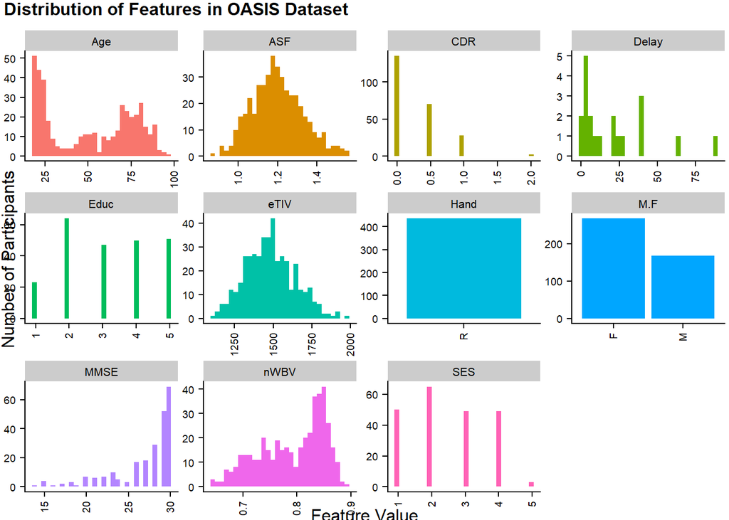

```r
# Function to emulate the ggplot default color palette for a given number of features
gg_color_hue <- function(n) {
  hues = seq(15, 375, length = n + 1)
  hcl(h = hues, l = 65, c = 100)[1:n]
}

# Function to create either a histogram or bar chart for each feature
# Depending on whether it's numerical or categorical, respectively
plot_func <- function(df, plot_list) {
  num_features <- length(colnames(df))
  plot_palette <- gg_color_hue(num_features)
  for (i in 1:length(colnames(df))) {
    feature <- sort(colnames(df))[i]
    if (is.numeric(df %>% pull(feature))) {
      feature_p <- df %>%
        dplyr::select(all_of(feature)) %>%
        dplyr::mutate(row_id = dplyr::row_number()) %>%
        pivot_longer(cols=c(-row_id),
                     names_to = "Variable",
                     values_to = "Raw_Value") %>%
        ggplot(data=., mapping=aes(x=Raw_Value)) +
        geom_histogram(fill = plot_palette[i])
    } else {
      feature_p <- df %>%
        dplyr::select(all_of(feature)) %>%
        dplyr::mutate(row_id = dplyr::row_number()) %>%
        pivot_longer(cols=c(-row_id),
                     names_to = "Variable",
                     values_to = "Value") %>%
        group_by(Variable, Value) %>%
        count() %>%
        ggplot(data=., mapping=aes(x = Value, y = n)) +
        geom_bar(stat = "identity", fill = plot_palette[i])
    }
    feature_p <- feature_p  +
      facet_wrap(Variable ~ ., scales="free") +
      theme(axis.text.x = element_text(angle=90, hjust=1, vjust=0.4, size=7),
            axis.text.y = element_text(size=7),
            plot.title = element_text(hjust=0.5, size=9),
            axis.title = element_blank(),
            strip.text = element_text(size=8),
            legend.position = "none")
    plot_list <- rlist::list.append(plot_list, feature_p)
  }

  return(plot_list)
}

# Generate list of plots, one per OASIS dataset feature (other than ID)
plot_list <- plot_func(oasis_data %>% dplyr::select(-ID),
                       list())

# Draw the plots
patchwork::wrap_plots(plot_list, ncol=4) + plot_annotation(
  title = 'Distribution of Features in OASIS Dataset'
) & theme(plot.margin = unit(c(0.05, 0.05, 0.05, 0.05), "cm"),
          plot.title = element_text(size=12))
grid::grid.draw(grid::textGrob("Number of Participants", x = 0.01, rot = 90))
grid::grid.draw(grid::textGrob("Feature Value", y = 0.01))
```

## 2.3 Exploration of Missing Data and Outliers

Now that the type and distribution of the variables has been characterised, it is vital to examine the frequency and distribution of missing data. This can be easily accomplished using the `naniar` package and the `vis_miss()` function:

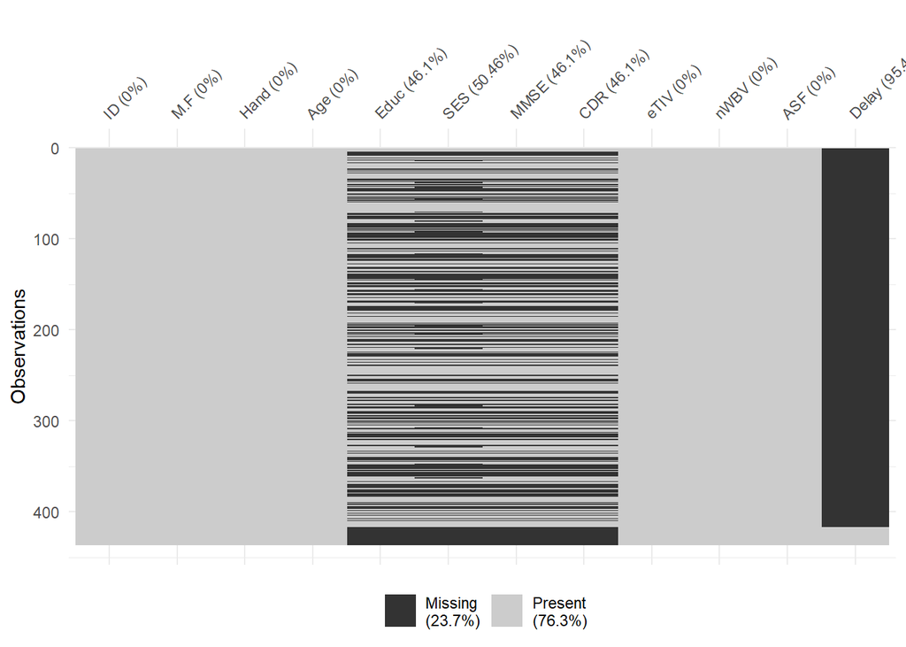

```r
naniar::vis_miss(oasis_data)
```

Importantly, this plot shows that for 46.1% (201) observations, `Educ`, `MMSE`, and `CDR` values are missing; for 50.46% (220) observations, `SES` is missing; and for 95.4% (416) of observations, `Delay` is missing. It makes sense for `Delay` to be missing for all but 20 observations, since there are only 20 validation follow-up visits in the dataset which have a corresponding delay time. However, missing data for the other four variables is not intuitively clear, and the author was unable to find any explicit rationale for this missing data in the corresponding [fact sheet](https://www.oasis-brains.org/files/oasis_cross-sectional_facts.pdf) or [journal publication](https://doi.org/10.1162/jocn.2007.19.9.1498).

In terms of outliers, we can visually estimate their presence using boxplots for the quantitative variables – `Age`, `MMSE`, `eTIV`, `nWBV`, `ASF`, and `Delay`:

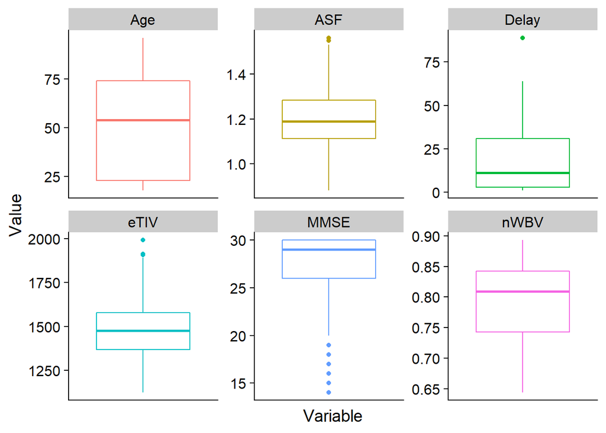

```r
oasis_data %>%
  dplyr::select(ID, Age, MMSE, eTIV, nWBV, ASF, Delay) %>%
  pivot_longer(cols = c(-ID), names_to = "Variable", values_to = "Value") %>%
  ggplot(data = ., mapping = aes(x = Variable, y = Value, color = Variable)) +
  geom_boxplot(fill = NA) +
  facet_wrap(Variable ~ ., scales = "free") +
  theme(legend.position = "none",
        axis.text.x = element_blank(),
        axis.ticks.x = element_blank())
```

## 2.4 Data Cleaning

As the primary goal for this project is to explore cross-sectional data from healthy and cognitively impaired participants, the first step for data cleaning will be to filter the data to only baseline visits (i.e. drop follow-up validation visits):

```r
oasis_data <- oasis_data %>%
  rowwise() %>%
  mutate(Subject_ID = str_split(ID, "_MR")[[1]][1],
         MR_Number = as.numeric(str_split(ID, "_MR")[[1]][2]),
         .keep = "unused") %>%
  filter(as.numeric(MR_Number) == 1)
```

After dropping those samples, here is the updated distribution of missing data:

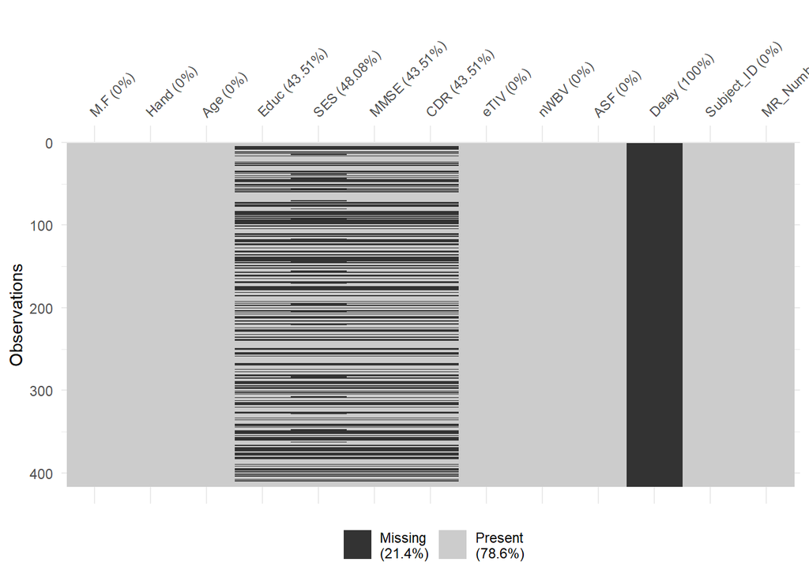

```r
naniar::vis_miss(oasis_data)
```

Clearly, the `Delay` column offers no information for the baseline visits, so that column will be dropped. Additionally, >40% of data is missing for `Educ`, `SES`, `MMSE`, and `CDR`, meaning it will be very difficult to accurately impute such data. For the purposes of this project, rows with `NA` values for these columns will also be dropped.

```r
oasis_data <- oasis_data %>%
  # Drop Delay
  dplyr::select(-Delay) %>%
  # Omit NA for Educ, SES, MMSE, and CDR
  tidyr::drop_na(c("Educ", "SES", "MMSE", "CDR"))
```

We can re-examine the structure of the cleaned OASIS data now:

```r
skimr::skim(oasis_data)
```

Data summary

| Name | oasis_data |
| --- | --- |
| Number of rows | 216 |
| Number of columns | 12 |
| _______________________ |  |
| Column type frequency: |  |
| character | 3 |
| numeric | 9 |
| ________________________ |  |
| Group variables | None |

**Variable type: character**

| skim_variable | n_missing | complete_rate | min | max | empty | n_unique | whitespace |
| --- | --- | --- | --- | --- | --- | --- | --- |
| M.F | 0 | 1 | 1 | 1 | 0 | 2 | 0 |
| Hand | 0 | 1 | 1 | 1 | 0 | 1 | 0 |
| Subject_ID | 0 | 1 | 9 | 9 | 0 | 216 | 0 |

**Variable type: numeric**

| skim_variable | n_missing | complete_rate | mean | sd | p0 | p25 | p50 | p75 | p100 | hist |
| --- | --- | --- | --- | --- | --- | --- | --- | --- | --- | --- |
| Age | 0 | 1 | 72.44 | 12.31 | 33.00 | 66.00 | 73.00 | 81.00 | 96.00 | ▁▂▃▇▃ |
| Educ | 0 | 1 | 3.23 | 1.33 | 1.00 | 2.00 | 3.00 | 4.00 | 5.00 | ▃▇▇▇▇ |
| SES | 0 | 1 | 2.49 | 1.12 | 1.00 | 2.00 | 2.00 | 3.00 | 5.00 | ▆▇▆▆▁ |
| MMSE | 0 | 1 | 27.32 | 3.44 | 15.00 | 26.00 | 29.00 | 30.00 | 30.00 | ▁▁▁▂▇ |
| CDR | 0 | 1 | 0.26 | 0.38 | 0.00 | 0.00 | 0.00 | 0.50 | 2.00 | ▇▃▂▁▁ |
| eTIV | 0 | 1 | 1458.64 | 160.52 | 1123.00 | 1346.00 | 1445.50 | 1536.50 | 1992.00 | ▂▇▅▂▁ |
| nWBV | 0 | 1 | 0.75 | 0.05 | 0.64 | 0.72 | 0.75 | 0.79 | 0.84 | ▃▆▇▇▆ |
| ASF | 0 | 1 | 1.22 | 0.13 | 0.88 | 1.14 | 1.21 | 1.30 | 1.56 | ▁▃▇▅▁ |
| MR_Number | 0 | 1 | 1.00 | 0.00 | 1.00 | 1.00 | 1.00 | 1.00 | 1.00 | ▁▁▇▁▁ |

Now there are no missing data across the features – albeit at the expense of omitting approximately half the participants for whom that data was missing. However, since the `Hand` column contains all “R” (i.e. all participants are right-handed), this column should also be dropped since it offers no added information:

```r
oasis_data <- dplyr::select(oasis_data, c(-Hand))
```

# 3. Research Question

## 3.1 Definition of research question

First, it is hypothesized that `MMSE` and `CDR` will be tightly correlated as they are both measures of cognitive function, and may therefore introduce redundancy to the data.

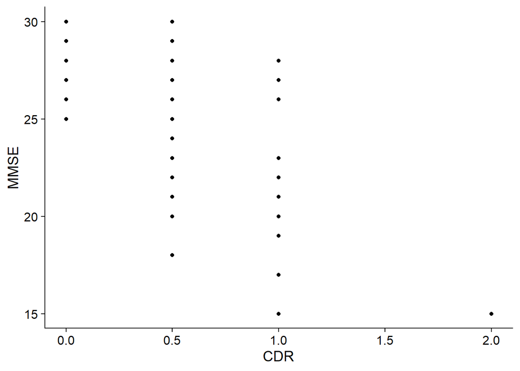

```r
oasis_data %>%
  ggplot(data = ., mapping = aes(x = CDR, y = MMSE)) +
  geom_point()
```

The correlation can be quantified using Spearman’s rho:

```r
cor.test(oasis_data$CDR, oasis_data$MMSE, method="spearman")
```

```
##
##  Spearman's rank correlation rho
##
## data:  oasis_data$CDR and oasis_data$MMSE
## S = 2838580, p-value < 2.2e-16
## alternative hypothesis: true rho is not equal to 0
## sample estimates:
##        rho
## -0.6900536
```

Since `MMSE` and `CDR` exhibit a moderately strong negative correlation ($\rho = -0.69, p<0.0001$), `MMSE` will be dropped as it is redundant to `CDR`.

```r
oasis_data <- oasis_data %>% dplyr::select(-MMSE)
```

To move forward with classification analysis, a binary variable (`has_dementia`) can be constructed from `CDR`:

```r
oasis_data <- oasis_data %>%
  dplyr::mutate(has_dementia = as.character(CDR > 0), .keep = "unused")

table(oasis_data$has_dementia)
```

```
##
## FALSE  TRUE
##   133    83
```

Of note, there are 83 participants with dementia and 133 participants without dementia. At this point, the `Subject_ID` and `MR_Number` columns can be dropped as the data is prepared for classification analysis and they are not relevant to classification:

```r
oasis_data <- dplyr::select(oasis_data, c(-Subject_ID, -MR_Number))
```

## 3.2 Comparing classification methods

```r
# Set seed for reproducibility
set.seed(127)

# Define training rows
training_index <- caret::createDataPartition(oasis_data$has_dementia, p = .75, list = FALSE)

# Separate out training and testing datasets
training_data <- oasis_data[training_index, ]
testing_data <- oasis_data[-training_index, ]
```

We can confirm that the proportion of healthy vs. demented participants is the same in the two datasets:

```r
prop.table(table(training_data$has_dementia))
```

```
##
##     FALSE      TRUE
## 0.6134969 0.3865031
```

```r
prop.table(table(testing_data$has_dementia))
```

```
##
##     FALSE      TRUE
## 0.6226415 0.3773585
```

The proportions are consisent, $\pm 1\%$. Now we can construct the two classification models, beginning with logistic regression:

```r
# Logistic regression
LR_model <- glm(factor(has_dementia) ~ ., data = training_data, family = 'binomial')

# Extract coefficients and significance
data.frame(coefs = round(LR_model$coefficients, 3),
           SE = round(summary(LR_model)$coefficients[,2], 3),
           pvals = summary(LR_model)$coefficients[,4]) %>%
  # Save rowname as new variable, "Term"
  tibble::rownames_to_column(var = "Term") %>%
  # Omit intercept
  dplyr::filter(Term != "(Intercept)") %>%
  # Add p-value stars according to standard conventions
  dplyr::mutate(stars = case_when(pvals < 0.0001 ~ "***",
                           pvals < 0.001 ~ "**",
                           pvals < 0.05 ~ "*",
                           T ~ ""),
                .keep = "unused") %>%
  arrange(coefs) %>%
  # Tidy up value as coefficient (SE), with stars as appropriate
  dplyr::mutate(`Coefficient (SE)` = paste0(coefs, stars, " (", SE, ")"),
                .keep = "unused") %>%
  # Style with knitr
  kable(.) %>%
  kable_styling(full_width = F)
```

| Term | Coefficient (SE) |
| --- | --- |
| nWBV | -24.31** (6.521) |
| Educ | -0.248 (0.219) |
| eTIV | 0.004 (0.009) |
| Age | 0.021 (0.025) |
| SES | 0.125 (0.26) |
| M.FM | 0.555 (0.489) |
| ASF | 3.71 (10.94) |

```r
# First make in-sample predictions as a baseline comparison
LR_train_pred_prob <- predict(LR_model, newdata = training_data, type = "response")
LR_train_preds <- ifelse(LR_train_pred_prob < 0.5, FALSE, TRUE)

# Then make out-of-sample predictions
LR_test_pred_prob <- predict(LR_model, newdata = testing_data, type = "response")
LR_test_preds <- ifelse(LR_test_pred_prob < 0.5, FALSE, TRUE)
```

A similar approach can be taken for the random forest classifier.

```r
set.seed(127)
RF_model <- randomForest(factor(has_dementia) ~ .,
                         type = "classification",
                         data=training_data,
                         ntree=100, mtry=3, importance=TRUE)
```

While random forest classifiers don’t yield coefficient estimates per variable, they do afford variable importance, which is derived from two factors: (1) increase in MSE when the given variable is omitted, indicating worse predictive performance without the variable; and (2) increase in node purity when variable is included, based on the GINI node impurity metric. These values can be visualized for the predictor terms:

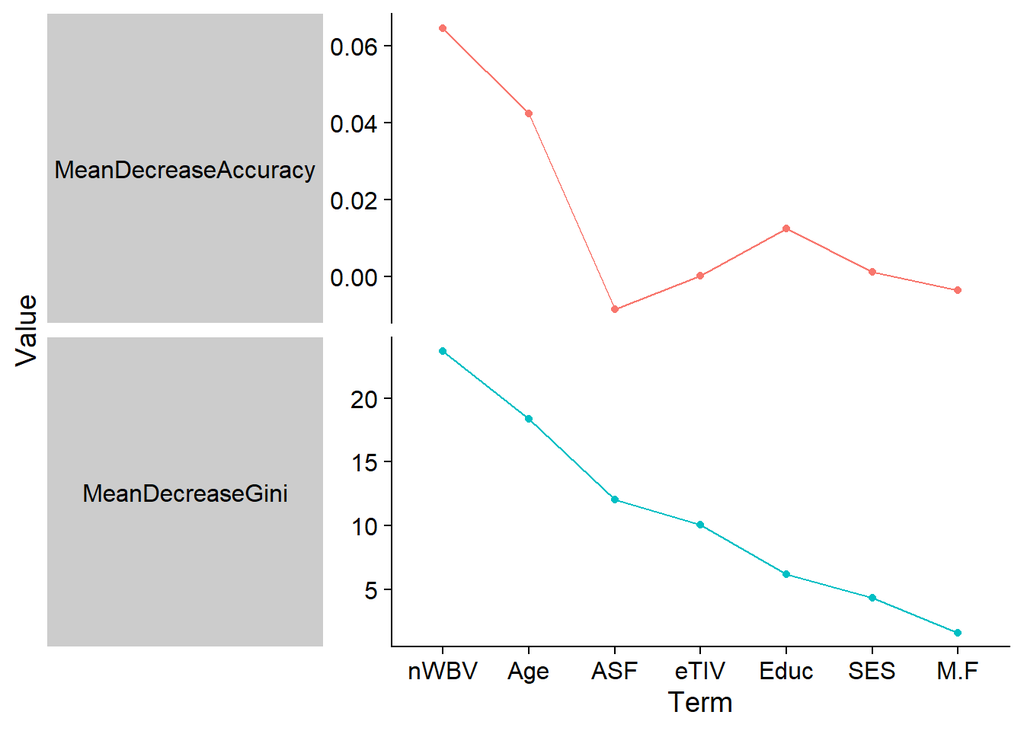

```r
as.data.frame(RF_model$importance) %>%
  dplyr::select(c(MeanDecreaseAccuracy, MeanDecreaseGini)) %>%
  rownames_to_column(var = "Term") %>%
  pivot_longer(cols = c(-Term),
               names_to = "Metric",
               values_to = "Value") %>%
  mutate(Term = fct_reorder(Term, Value, .desc = T)) %>%
  ggplot(data = ., mapping = aes(x = Term, y = Value,
                                 group = Metric,
                                 color = Metric)) +
  geom_line() +
  geom_point(size=1.5) +
  facet_grid(Metric ~ ., scales = "free_y", switch = "both") +
  theme(legend.position = "none",
        strip.text.y.left = element_text(angle=0),
        strip.placement = "outside")
```

Across both metrics, `nWBV` is the most important predictor term, which is in keeping with the logistic regression coefficient results. `Age` is the next most important predictor term, which is interesting given its low-magnitude coefficient (0.021) in the logistic regression model. The other five predictor terms have much lower values for both metrics in this figure, indiciating they are of lower importance to the random forest. The last step is to generate predictions for the unseen test dataset based on the RF constructed from the training dataset:

```r
# First make in-sample predictions as a baseline comparison
RF_train_preds <- predict(RF_model, newdata = training_data, type = "response")

# Then make out-of-sample predictions
RF_test_preds <- predict(RF_model, newdata = testing_data, type = "response")
```

## 3.3 Results

Predictive accuracy can be assessed by predicting classes on the test set and computing a confusion matrix to compare predictions with the actual class labels.

Now that the two binary classification models have been applied to the testing data, their respective predictive performances can be compared. Since this is a binary classification task, predictive performance can be quantified as the accuracy between true labels (dementia vs. no dementia) and predicted labels in the training and testing datasets.

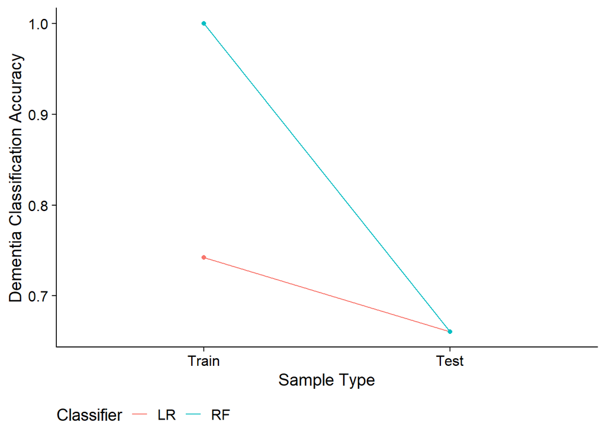

```r
# Tabulate training data classification accuracy results
training_data_res <- training_data %>%
  dplyr::rename("Real" = "has_dementia") %>%
  dplyr::mutate(Real = as.logical(Real)) %>%
  dplyr::mutate("LR_train_predicted" = as.logical(LR_train_preds),
                "RF_train_predicted" = as.logical(RF_train_preds)) %>%
  dplyr::summarise(LR_train_accuracy = sum(LR_train_predicted == Real)/n(),
                   RF_train_accuracy = sum(RF_train_predicted == Real)/n())

# Tabulate test data classification accuracy results
testing_data_res <- testing_data %>%
  dplyr::rename("Real" = "has_dementia") %>%
  dplyr::mutate(Real = as.logical(Real)) %>%
  dplyr::mutate("LR_test_predicted" = LR_test_preds,
                "RF_test_predicted" = RF_test_preds) %>%
  dplyr::summarise(LR_test_accuracy = sum(LR_test_predicted == Real)/n(),
                   RF_test_accuracy = sum(RF_test_predicted == Real)/n())

# Merge results for visualization
cbind(training_data_res, testing_data_res) %>%
  pivot_longer(cols = everything(),
               names_to = "Metric",
               values_to = "Accuracy") %>%
  mutate(Sample_Type = ifelse(str_detect(Metric, "train"), "Train", "Test"),
         Classifier = ifelse(str_detect(Metric, "LR"), "LR", "RF"),
         .keep = "unused") %>%
  mutate(Sample_Type = factor(Sample_Type,
                              levels = c("Train", "Test"))) %>%
  ggplot(data = ., mapping = aes(x = Sample_Type, y = Accuracy,
                                 group = Classifier, color = Classifier)) +
  geom_line() +
  geom_point(show.legend = F) +
  xlab("Sample Type") +
  ylab("Dementia Classification Accuracy") +
  theme(legend.position = "bottom")
```

As is expected, both classifiers perform better when applied to the in-sample training dataset than the out-of-sample testing dataset. Interestingly, the RF classifier achieved 100% in-sample accuracy while the LR classifier achieved only 74.23% in-sample accuracy; for the out-of-sample testing data, both algorithms achieved the same accuracy (66.04%). It is important to note that there are class imbalances in the data, as the OASIS dataset used here is comprised of 61.57% non-dementia and 38.43% dementia participants; however, the out-of-sample accuracy values are higher than the non-dementia proportion, suggesting the classifiers are not merely labelling all samples as non-dementia.

```r
#LR
cat("\nLR confusion matrix:\n")
```

```
##
## LR confusion matrix:
```

```r
caret::confusionMatrix(data=as.factor(LR_test_preds), reference=as.factor(testing_data$has_dementia))
```

```
## Confusion Matrix and Statistics
##
##           Reference
## Prediction FALSE TRUE
##      FALSE    22    7
##      TRUE     11   13
##
##                Accuracy : 0.6604
##                  95% CI : (0.5173, 0.7848)
##     No Information Rate : 0.6226
##     P-Value [Acc > NIR] : 0.3391
##
##                   Kappa : 0.3047
##
##  Mcnemar's Test P-Value : 0.4795
##
##             Sensitivity : 0.6667
##             Specificity : 0.6500
##          Pos Pred Value : 0.7586
##          Neg Pred Value : 0.5417
##              Prevalence : 0.6226
##          Detection Rate : 0.4151
##    Detection Prevalence : 0.5472
##       Balanced Accuracy : 0.6583
##
##        'Positive' Class : FALSE
##
```

```r
#RF
cat("\nRF confusion matrix:\n")
```

```
##
## RF confusion matrix:
```

```r
caret::confusionMatrix(data=as.factor(RF_test_preds), reference=as.factor(testing_data$has_dementia))
```

```
## Confusion Matrix and Statistics
##
##           Reference
## Prediction FALSE TRUE
##      FALSE    20    5
##      TRUE     13   15
##
##                Accuracy : 0.6604
##                  95% CI : (0.5173, 0.7848)
##     No Information Rate : 0.6226
##     P-Value [Acc > NIR] : 0.33912
##
##                   Kappa : 0.3301
##
##  Mcnemar's Test P-Value : 0.09896
##
##             Sensitivity : 0.6061
##             Specificity : 0.7500
##          Pos Pred Value : 0.8000
##          Neg Pred Value : 0.5357
##              Prevalence : 0.6226
##          Detection Rate : 0.3774
##    Detection Prevalence : 0.4717
##       Balanced Accuracy : 0.6780
##
##        'Positive' Class : FALSE
##
```

# 4. Conclusions

## 4.1 Summary of findings

In this report, an open-access cognitive and neuroimaging biomarker dataset was leveraged to analyse prediction performance in classifying cognitively healthy older adults versus adults with dementia. Two distinct binary classifiers yielded identical out-of-sample classification accuracy (66.04%) using the final set of seven input features: sex, age, highest level of education, socioeconomic status, intracranial volume, normalized whole-brain volume, and atlas scaling factor. Both classifiers highlighted normalized whole-brain volume, with LR yielding the largest-magnitude coefficient and RF yielding the largest variable importance. This is consistent with [prior peer-reviewed literature](https://doi.org/10.1001%2Farchneurol.2011.192) reporting a positive linear association between nWBV and cognitive performance.

## 4.2 Remarks on data wrangling

Data tidying and wrangling techniques were implemented at each step of the analysis and ultimately formed the bedrock of this project. The majority of tools utilized herein come from the `tidyverse` suite of packages; perhaps one of the most useful is the combination of `pivot_longer` and `pivot_wider` from `tidyr`, which enables the data to be quickly transposed from wide to long – and perhaps back to wide again – for data summarisation purposes. In this analysis alone, `pivot_longer` was called five times, particularly since the original dataset came in a tidy but wide format.

In order to prepare the OASIS dataset for binary classification analysis with LR and RF models, data wrangling was implemented at several steps: to filter observations to only the baseline visit per participant, to omit columns with no unique values (e.g. Delay, Hand), o drop observations with `NA` values to ensure data completeness, and to construct the `has_dementia` feature. Data visualization served as a key tool to elucidate the underlying structure of the data, and wrangling was used to organise facet plots for histogram or boxplot visuals. The results from the LR and RF models were also integrated using wrangling tools, for both table and plot outputs.

Data wrangling tools enable the efficient and elegant transformation from original dataset to graphical outputs and model interpretations with minimal code – for example, for the entire workflow presented herein, only 210 lines of code were utilized. By leaving behind a code “paper trail” during data manipulation, the exact same analyses can be easily replicated on multiple datasets, which is vital to ensure consistency and precision in multi-dataset projects.